# Diamond Price Analysis

### Model 1 - Prior predictive check

**Return to table of contents**

First step is prior predicive check whether parameter values and distributions "make sense".

Parameters simulated from priors are a result of the model definition.

Priors were selected experimentally, starting with small, typical distributions (eg. Normal(0,10)) up to final values based on resultant plot.

On the basis of the obtained parameter values, it can be concluded that the prior selection was successful, the values are in line with the expectations.

#### PPC stan code:

[figure not shown]

```python
model_1_prior=CmdStanModel(stan_file='Stan_files/model_1_prior.stan')
```

```
00:56:41 - cmdstanpy - INFO - compiling stan file C:\Users\jkwap\Desktop\Sem_I\DA\Project\data_analitics\Stan_files\model_1_prior.stan to exe file C:\Users\jkwap\Desktop\Sem_I\DA\Project\data_analitics\Stan_files\model_1_prior.exe
00:58:07 - cmdstanpy - INFO - compiled model executable: C:\Users\jkwap\Desktop\Sem_I\DA\Project\data_analitics\Stan_files\model_1_prior.exe
```

```python
X = 1000
N = dataFrame.shape[0]
engine_size_data = dataFrame['Engine Size(L)']
cylinders_data = dataFrame['Cylinders']
drag_coeficient_data = dataFrame['Drag coefficient']
fuel_consumption_data = dataFrame['Fuel Consumption(Hwy (L/100 km))']
```

```python
samples_1_prior = model_1_prior.sample(data = {'N':N, 'engine_size':engine_size_data, 'drag_coeficient':drag_coeficient_data},
iter_sampling=X,
iter_warmup=2000,
chains=1,
seed=29042020,
refresh=N)
```

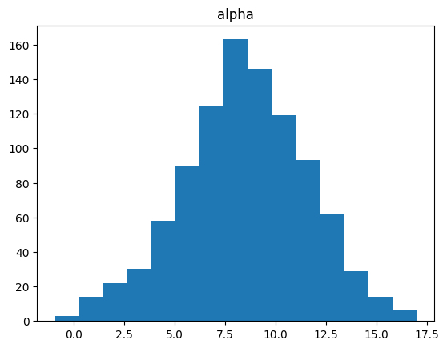

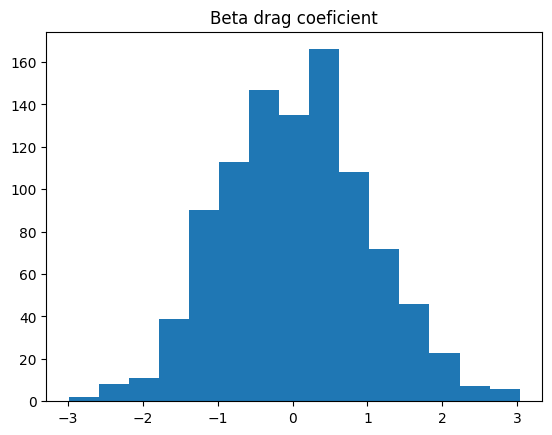

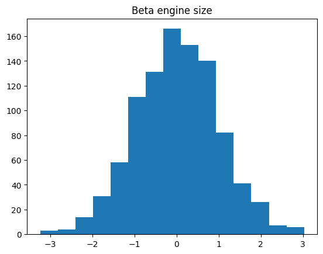

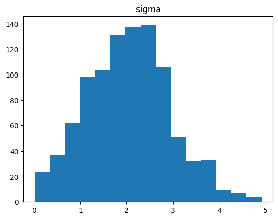

```python
dataFrame_model_1_prior = samples_1_prior.draws_pd()
plt.figure(0)
plt.hist(dataFrame_model_1_prior.alpha,bins=15)
plt.title('alpha')
plt.figure(1)
plt.hist(dataFrame_model_1_prior.beta_drag_coeficient,bins=15)
plt.title('Beta drag coeficient')
plt.figure(2)
plt.hist(dataFrame_model_1_prior.beta_engine_size,bins=15)
plt.title('Beta engine size')
plt.figure(3)
plt.hist(dataFrame_model_1_prior.sigma,bins=15)
plt.title('sigma')
plt.show()
```

### Model 1 - Comparing margin prior values with data

**Return to table of contents**

```python
def calcQuants(x, y):
    qlvls = [0, 1]
    quansList = [[], []]
    for i in range(y.shape[-1]):
        temp = y[:, i]
        for q, lvl in zip(quansList, qlvls):
            q.append(np.quantile(temp, lvl))
    return quansList

def quantsExtremes(df, y, q):
    engine_uq = df['Engine Size(L)'].unique()
    engine_uq = sorted(engine_uq)
    quansList = calcQuants(df['Engine Size(L)'], y)
    engineQuantDict = dict()
    for engine_val in engine_uq:
        engineList = np.array(df['Engine Size(L)'].tolist())
        idxs = np.where(engineList == engine_val)[0]
        qval = quansList[q][idxs[0]]
        for i in idxs:
            if q == 0 and quansList[q][i] < qval:
                qval = quansList[q][i]
            elif q == 1 and quansList[q][i] > qval:
                qval = quansList[q][i]
        engineQuantDict[engine_val] = qval
    return engineQuantDict
```

[figure not shown]

```python
plt.figure(figsize=[10, 6])

price_sim = samples_1_prior.stan_variable('fuel_consumption')

engQuantMinDict = quantsExtremes(dataFrame, price_sim, 0)
engMin = (engQuantMinDict.keys())
quantMin = (engQuantMinDict.values())

engQuantMaxDict = quantsExtremes(dataFrame, price_sim, 1)
engMax = (engQuantMaxDict.keys())
quantMax = (engQuantMaxDict.values())

plt.figure(figsize=[10, 6])
plt.plot(engMin, quantMin, color='purple')
plt.plot(engMax, quantMax, color='orange')
plt.scatter(dataFrame['Engine Size(L)'], dataFrame['Fuel Consumption(Hwy (L/100 km))'], color='black', alpha=0.2, s=10)
plt.xlabel("Engine size")
plt.ylabel("Fuel consumption")
plt.title("Model 1 - Prior predictive check")
plt.legend(['min', 'max', 'data'])
plt.grid()
plt.show()
```

### Model 1 - Posterior analysis

**Return to table of contents**

After confirming that the priors values and trajectories are correct we can start a proper analysis.

#### Posterior stan code:

[figure not shown]

```python
model_1_post=CmdStanModel(stan_file='Stan_files/model_1_post.stan')
```

```python
samples_1_post = model_1_post.sample(data = {'N':N, 'engine_size':engine_size_data, 'drag_coeficient':drag_coeficient_data, 'cylinders':cylinders_data, 'fuel_consumption':fuel_consumption_data},
iter_sampling=X,
iter_warmup=200,
chains=1,
seed=29042020,
refresh=N)
```

```
02:41:24 - cmdstanpy - INFO - CmdStan start processing
chain 1 |██████████| 00:08 Sampling completed
```

```
02:41:32 - cmdstanpy - INFO - CmdStan done processing.
```

### Model 1 - model parameters

**Return to table of contents**

We can also extract stan variables that are used in the final fuel consumption prediction equation.

Based on the presented graphs and histograms of parameters, it can be concluded that parameter values are relatively concentrated.

Their slight dispersion is indicative of the cars in the same class being slightly different from one another.

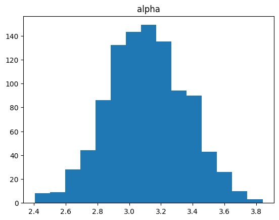

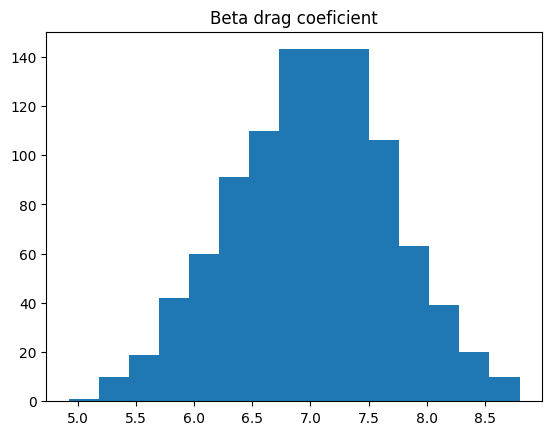

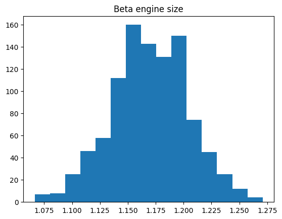

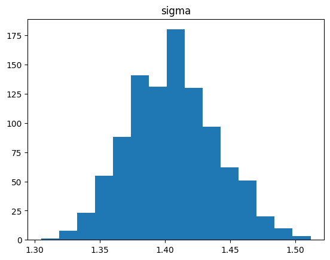

```python
dataFrame_model_1_post = samples_1_post.draws_pd()

plt.figure(0)
plt.hist(dataFrame_model_1_post.alpha,bins=15)
plt.title('alpha')
plt.figure(1)
plt.hist(dataFrame_model_1_post.beta_drag_coeficient,bins=15)
plt.title('Beta drag coeficient')
plt.figure(2)
plt.hist(dataFrame_model_1_post.beta_engine_size,bins=15)
plt.title('Beta engine size')
plt.figure(3)
plt.hist(dataFrame_model_1_post.sigma,bins=15)
plt.title('sigma')
plt.show()
```

### Model 1 - evaluation

**Return to table of contents**

We can now observe the results.

#### Model 1 - quantiles

**Return to table of contents**

After simulating we can analyze predictions. Most of the simulated cars fall within real data ranges.

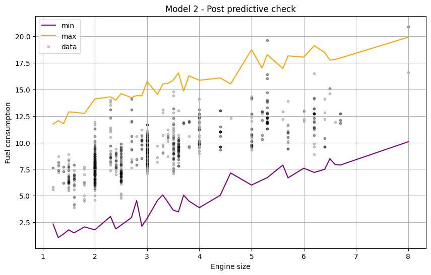

```python
plt.figure(figsize=[10, 6])

price_sim = samples_1_post.stan_variable('y_out')

engQuantMinDict = quantsExtremes(dataFrame, price_sim, 0)
engMin = (engQuantMinDict.keys())
quantMin = (engQuantMinDict.values())

engQuantMaxDict = quantsExtremes(dataFrame, price_sim, 1)
engMax = (engQuantMaxDict.keys())
quantMax = (engQuantMaxDict.values())

plt.figure(figsize=[10, 6])
plt.plot(engMin, quantMin, color='purple')
plt.plot(engMax, quantMax, color='orange')
plt.scatter(dataFrame['Engine Size(L)'], dataFrame['Fuel Consumption(Hwy (L/100 km))'], color='black', alpha=0.2, s=10)
plt.xlabel("Engine size")
plt.ylabel("Fuel consumption")
plt.title("Model 2 - Post predictive check")
plt.legend(['min', 'max', 'data'])
plt.grid()
plt.show()
```

#### Model 1 - predictions and density plot

**Return to table of contents**

As seen on the plots the model is somewhat sufficient. It describes most accurately cars with common engine sizes. Despite this, fuel consumption figures are quite scattered.

Perhaps adding another predictor could solve the issue.

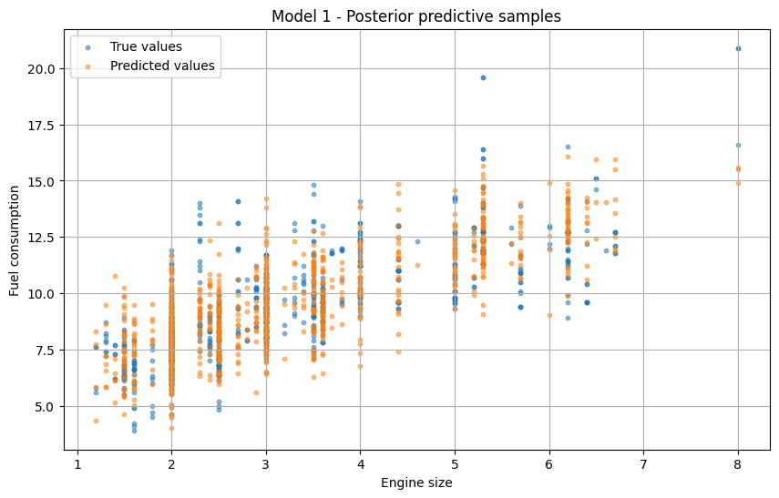

```python
price_sim = samples_1_post.stan_variable('y_out')
plt.figure(figsize=[10,6])
plt.scatter(engine_size_data, fuel_consumption_data, alpha=0.5, s=10)
plt.scatter(engine_size_data, price_sim[0], alpha=0.5, s=10)
plt.title("Model 1 - Posterior predictive samples")
plt.legend(["True values", "Predicted values"])
plt.xlabel("Engine size")
plt.ylabel("Fuel consumption")
plt.grid()
plt.show()
```

[output not shown]

[output not shown]

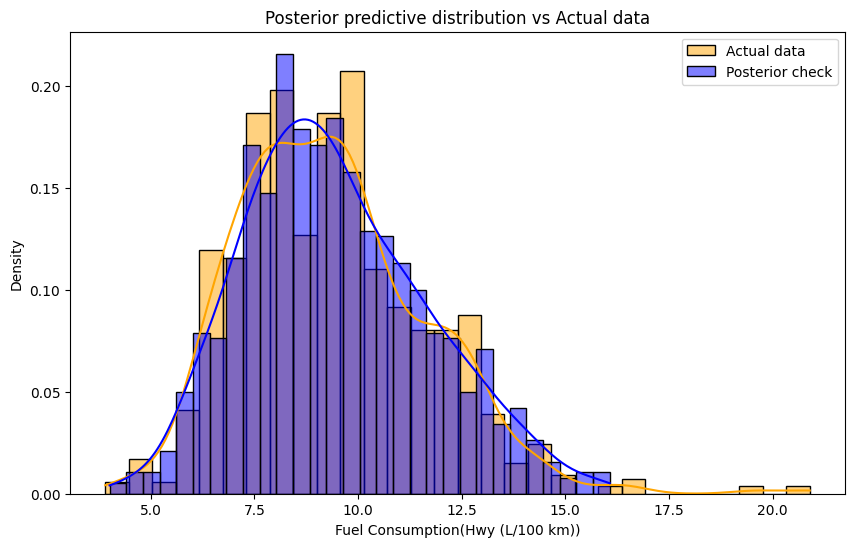

```python
dataFrame_model_1_post = samples_1_post.draws_pd()

list = []
for i in range(1,N):
    val = dataFrame_model_1_post['y_out[' + str(i)+ ']'].mean()
    list.append(val)

actual_data_flat = fuel_consumption_data
plt.figure(figsize=(10,6))
sns.histplot(actual_data_flat, bins =30, kde=True, stat='density', alpha=0.5,label='Actual data', color='orange')
sns.histplot(list, bins =30, kde=True, stat='density', alpha=0.5,label='Posterior check', color='blue')
plt.legend()
plt.title('Posterior predictive distribution vs Actual data')
```

## Model 2 - three predictors

**Return to table of contents**

Model has form:

$$ price_i \sim \mathrm{Normal}(\mu_i,\sigma) $$ $$ \mu_i = \alpha + \beta_{engine \,size}[engine \,size_i] + \beta_{drag \,coefficient}[drag \,coefficient_i] + \beta_{cylinders \,number_i}[cylinders \,number_i]$$

With parameter distributions set as follows: $$ \alpha \sim \mathrm{Normal}(8.5, 3) $$ $$ \beta_{engine \,size} \sim \mathrm{Normal}(0, 1) $$ $$ \beta_{drag \,coefficient} \sim \mathrm{Normal}(0, 1) $$ $$ \beta_{cylinders \,number} \sim \mathrm{Normal}(0, 1) $$ $$ \sigma \sim \mathrm{Normal}(2, 1) $$

The required input data is the set of cars with engine size, cylinders number and drag coefficient for which the user wants to make a prediction.

### Model 2 - Prior predictive check

**Return to table of contents**

First step is prior predicive check whether parameter values and distributions "make sense".

Parameters simulated from priors are a result of the model definition.

Some priors are derived from the first model as the second one is it's expansion. Rest of which were selected experimentally following the same procedure, starting with small, typical distributions (eg. Normal(0,10)) up to final values based on resultant plot.

On the basis of the obtained parameter values, it can be concluded that the prior selection was successful, the values are in line with the expectations.

#### PPC stan code:

[figure not shown]

```python
model_2_prior=CmdStanModel(stan_file='Stan_files/model_2_prior.stan')
```

```
02:19:31 - cmdstanpy - INFO - compiling stan file C:\Users\jkwap\Desktop\Sem_I\DA\Project\data_analitics\Stan_files\model_2_prior.stan to exe file C:\Users\jkwap\Desktop\Sem_I\DA\Project\data_analitics\Stan_files\model_2_prior.exe
02:20:33 - cmdstanpy - INFO - compiled model executable: C:\Users\jkwap\Desktop\Sem_I\DA\Project\data_analitics\Stan_files\model_2_prior.exe
```

```python
samples_2_prior = model_2_prior.sample(data = {'N':N, 'engine_size':engine_size_data, 'drag_coeficient':drag_coeficient_data, 'cylinders':cylinders_data},
iter_sampling=X,
iter_warmup=2000,
chains=1,
seed=29042020,
refresh=N)
```

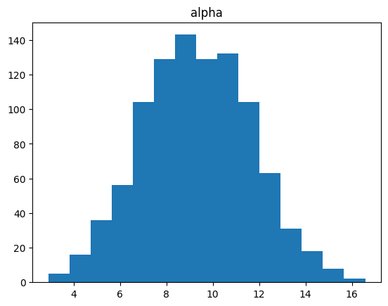

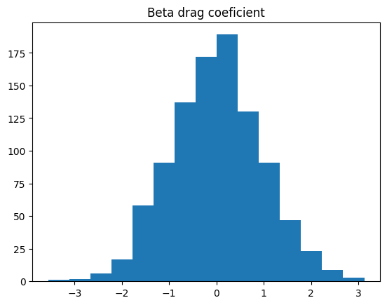

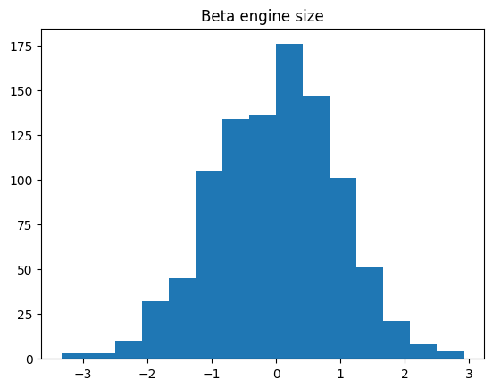

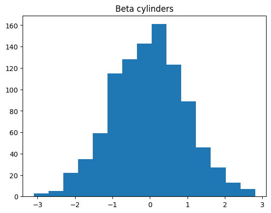

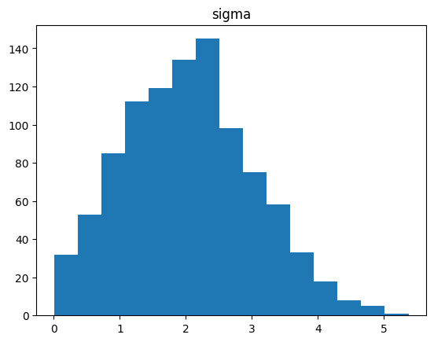

```python
dataFrame_model_2_prior = samples_2_prior.draws_pd()

plt.figure(0)
plt.hist(dataFrame_model_2_prior.alpha,bins=15)
plt.title('alpha')
plt.figure(1)
plt.hist(dataFrame_model_2_prior.beta_drag_coeficient,bins=15)
plt.title('Beta drag coeficient')
plt.figure(2)
plt.hist(dataFrame_model_2_prior.beta_engine_size,bins=15)
plt.title('Beta engine size')
plt.figure(3)
plt.hist(dataFrame_model_2_prior.beta_cylinders,bins=15)
plt.title('Beta cylinders')
plt.figure(4)
plt.hist(dataFrame_model_2_prior.sigma,bins=15)
plt.title('sigma')
plt.show()
```

### Model 2 - Comparing margin prior values with data

**Return to table of contents**

[figure not shown]

```python
plt.figure(figsize=[10, 6])

price_sim = samples_2_prior.stan_variable('fuel_consumption')

caratQuantMinDict = quantsExtremes(dataFrame, price_sim, 0)
caratMin = (caratQuantMinDict.keys())
quantMin = (caratQuantMinDict.values())

caratQuantMaxDict = quantsExtremes(dataFrame, price_sim, 1)
caratMax = (caratQuantMaxDict.keys())
quantMax = (caratQuantMaxDict.values())

plt.figure(figsize=[10, 6])
plt.plot(caratMin, quantMin, color='purple')
plt.plot(caratMax, quantMax, color='orange')
plt.scatter(dataFrame['Engine Size(L)'], dataFrame['Fuel Consumption(Hwy (L/100 km))'], color='black', alpha=0.2, s=10)
plt.xlabel("Engine size")
plt.ylabel("Fuel consumption")
plt.title("Model 2 - Prior predictive check")
plt.legend(['min', 'max', 'data'])
plt.grid()
plt.show()
```

### Model 2 - Posterior analysis

**Return to table of contents**

After confirming that the priors values and trajectories are correct we can start a proper analysis.

#### Posterior stan code:

[figure not shown]

```python
model_2_post=CmdStanModel(stan_file='Stan_files/model_2_post.stan')
```

```python
samples_2_post = model_2_post.sample(data = {'N':N, 'engine_size':engine_size_data, 'drag_coeficient':drag_coeficient_data, 'cylinders':cylinders_data, 'fuel_consumption':fuel_consumption_data},
iter_sampling=X,
iter_warmup=200,
chains=1,
seed=29042020,
refresh=N)
```

```
02:39:31 - cmdstanpy - INFO - CmdStan start processing
chain 1 |██████████| 00:36 Sampling completed
```

```
02:40:08 - cmdstanpy - INFO - CmdStan done processing.
```

### Model 2 - model parameters

**Return to table of contents**

We can also extract stan variables that are used in the final fuel consumption prediction equation.

Based on the presented graphs and histograms of parameters, it can be concluded that parameter values are relatively concentrated.

Their slight dispersion is indicative of the cars in the same class being slightly different from one another.

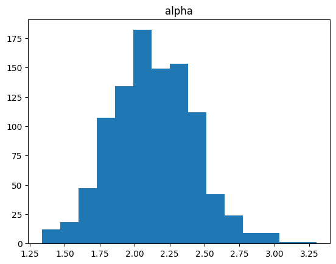

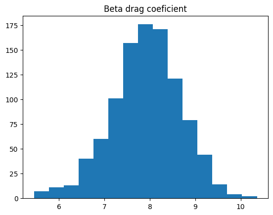

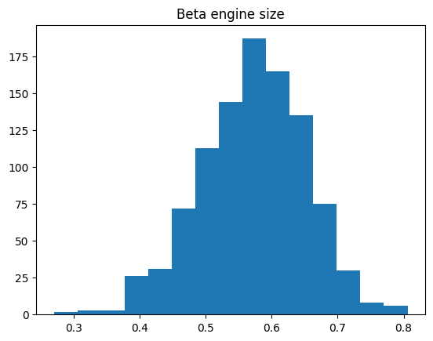

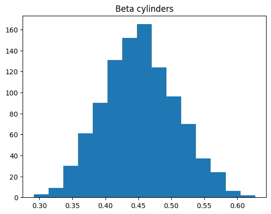

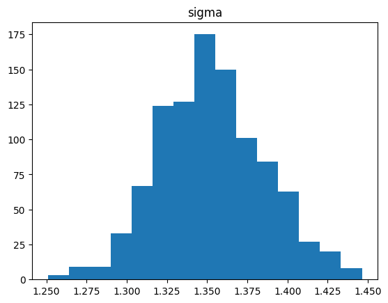

```python
dataFrame_model_2_post = samples_2_post.draws_pd()

plt.figure(0)
plt.hist(dataFrame_model_2_post.alpha,bins=15)
plt.title('alpha')
plt.figure(1)
plt.hist(dataFrame_model_2_post.beta_drag_coeficient,bins=15)
plt.title('Beta drag coeficient')
plt.figure(2)
plt.hist(dataFrame_model_2_post.beta_engine_size,bins=15)
plt.title('Beta engine size')
plt.figure(3)
plt.hist(dataFrame_model_2_post.beta_cylinders,bins=15)
plt.title('Beta cylinders')
plt.figure(4)
plt.hist(dataFrame_model_2_post.sigma,bins=15)
plt.title('sigma')
plt.show()
```

### Model 2 - evaluation

**Return to table of contents**

We can now observe the results.

#### Model 2 - quantiles

**Return to table of contents**

After simulating we can analyze predictions. Most of the simulated values fall within real data ranges.

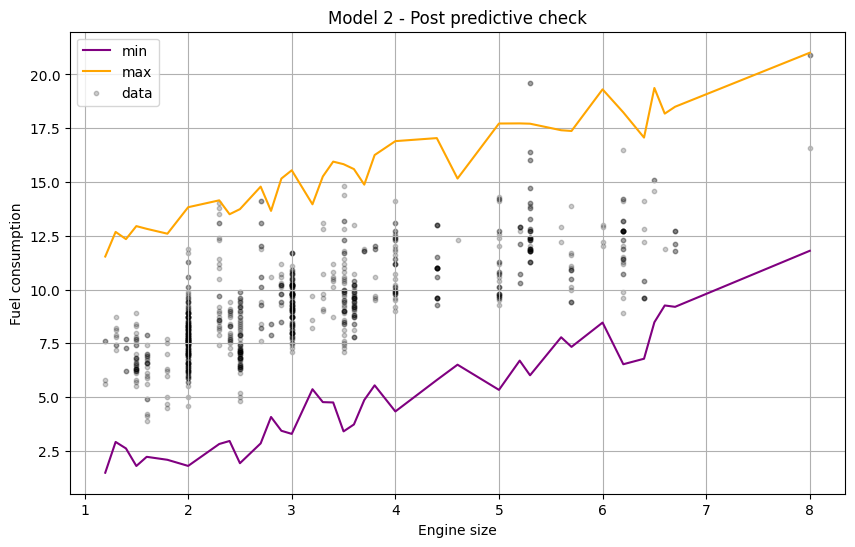

```python
plt.figure(figsize=[10, 6])

price_sim = samples_2_post.stan_variable('y_out')

caratQuantMinDict = quantsExtremes(dataFrame, price_sim, 0)
caratMin = (caratQuantMinDict.keys())
quantMin = (caratQuantMinDict.values())

caratQuantMaxDict = quantsExtremes(dataFrame, price_sim, 1)
caratMax = (caratQuantMaxDict.keys())
quantMax = (caratQuantMaxDict.values())

plt.figure(figsize=[10, 6])
plt.plot(caratMin, quantMin, color='purple')
plt.plot(caratMax, quantMax, color='orange')
plt.scatter(dataFrame['Engine Size(L)'], dataFrame['Fuel Consumption(Hwy (L/100 km))'], color='black', alpha=0.2, s=10)
plt.xlabel("Engine size")
plt.ylabel("Fuel consumption")
plt.title("Model 2 - Post predictive check")
plt.legend(['min', 'max', 'data'])
plt.grid()
plt.show()
```

#### Model 2 - predictions and density plot

**Return to table of contents**

As we can see the model is slightly better than the first one.

Predictions seem to be more concentrated around real values while having more true-to-dataset deviation.

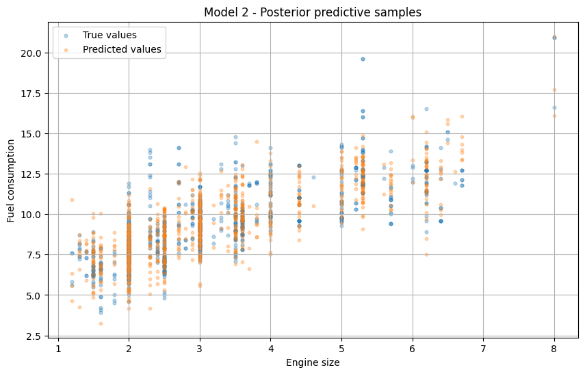

```python
price_sim = samples_2_post.stan_variable('y_out')
plt.figure(figsize=[10,6])
plt.scatter(engine_size_data, fuel_consumption_data, alpha=0.3, s=12)
plt.scatter(engine_size_data, price_sim[0], alpha=0.3, s=10)
plt.title("Model 2 - Posterior predictive samples")
plt.legend(["True values", "Predicted values"])
plt.xlabel("Engine size")
plt.ylabel("Fuel consumption")
plt.grid()
plt.show()
```

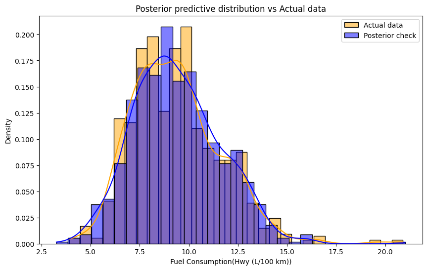

```python
dataFrame_model_2_post = samples_2_post.draws_pd()

list = []
for i in range(1,N):
    val = dataFrame_model_2_post['y_out[' + str(i)+ ']'].mean()
    list.append(val)

actual_data_flat = fuel_consumption_data
plt.figure(figsize=(10,6))
sns.histplot(actual_data_flat, bins =30, kde=True, stat='density', alpha=0.5,label='Actual data', color='orange')
sns.histplot(list, bins =30, kde=True, stat='density', alpha=0.5,label='Posterior check', color='blue')
plt.legend()
plt.title('Posterior predictive distribution vs Actual data')
```

## Model Comparison

**Return to table of contents**

Leave-one-out cross-validation (LOO) and the widely applicable information criterion (WAIC) are methods for estimating pointwise out-of-sample prediction accuracy from a fitted Bayesian model using the log-likelihood evaluated at the posterior simulations of the parameter values. The comparison function used allows the models to be assessed against each of these criteria, ordering them from best to worst.

### PSIS-LOO Criterion

**Return to table of contents**

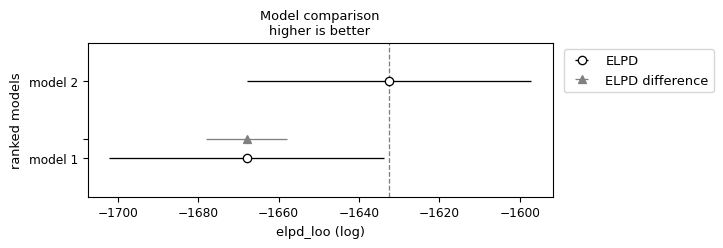

```python
compare=az.compare({'model 1':samples_1_post,'model 2':samples_2_post}, ic='loo')
az.plot_compare(compare)
```

### WAIC Criterion

**Return to table of contents**

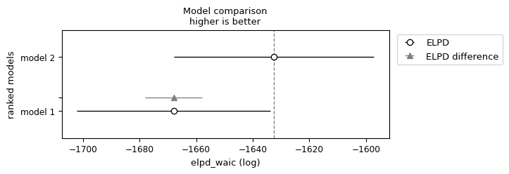

```python
compare=az.compare({'model 1':samples_1_post,'model 2':samples_2_post}, ic='waic')
az.plot_compare(compare)
```

### Model Comparison - conclusions

**Return to table of contents**

Comparing the models, both visually and by criteria, we can agree that both models can be used in different applications. Differences are rather small and that may be caused by strong connections between two of predictors. Overall accuracy of predictions may be improved by increasing number of independent predictors.